# Characteristics of Different Democracy Measures

## Distribution

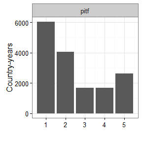

```r
ggplot(data = data) +
  geom_bar(aes(x=value)) +
  theme_bw() +
  theme(legend.position = "bottom") +
  labs(y = "Country-years", x="") +
  facet_wrap(~variable, ncol=2)
```

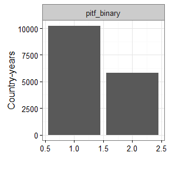

```r
data <- democracy_long %>% filter(variable == "pitf_binary")

ggplot(data = data) +
  geom_bar(aes(x=value)) +
  theme_bw() +
  theme(legend.position = "bottom") +
  labs(y = "Country-years", x="") +
  facet_wrap(~variable, ncol=2)
```

# Polity

These are variables from the Polity IV dataset in country-year format, updated to 2014 (Marshall, Gurr, and Jaggers 2012).

## Coverage

```r
data <- democracy_long %>% filter(variable == "polity")

temporal_coverage(data)
```

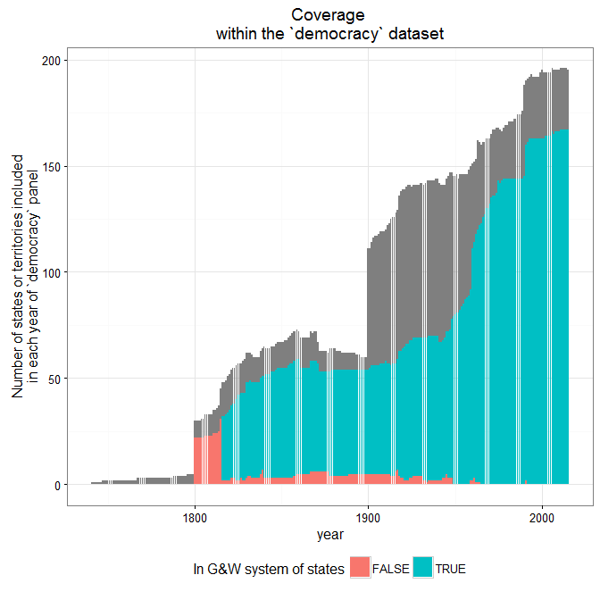

```r
spatial_coverage(data)
```

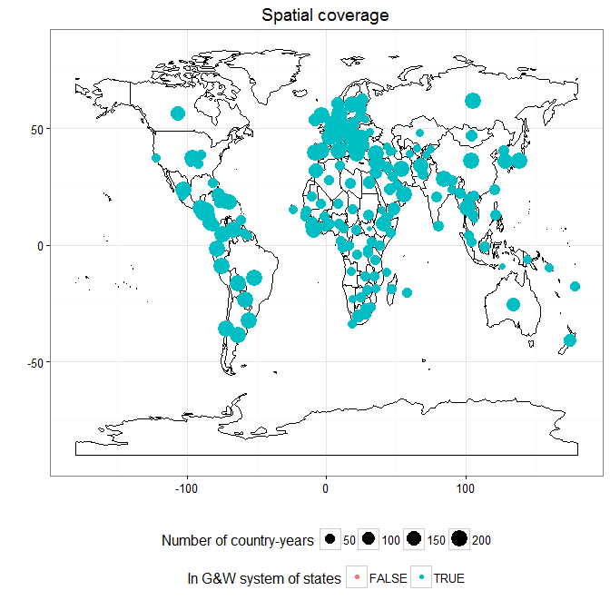

## Distribution

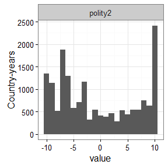

```r
data <- democracy_long %>% filter(variable == "polity2")

ggplot(data = data) +
  geom_histogram(aes(x=value),binwidth=1) +
  theme_bw() +
  theme(legend.position = "bottom") +
  labs(y = "Country-years") +
  facet_wrap(~variable, ncol=2)
```

# Polyarchy

The dataset from Coppedge and Reinicke 1991, revised in 2003-2006 with a new “contestation” measure.

## Coverage

```r
data <- democracy_long %>% filter(variable == "polyarchy_reversed")

temporal_coverage(data)
```

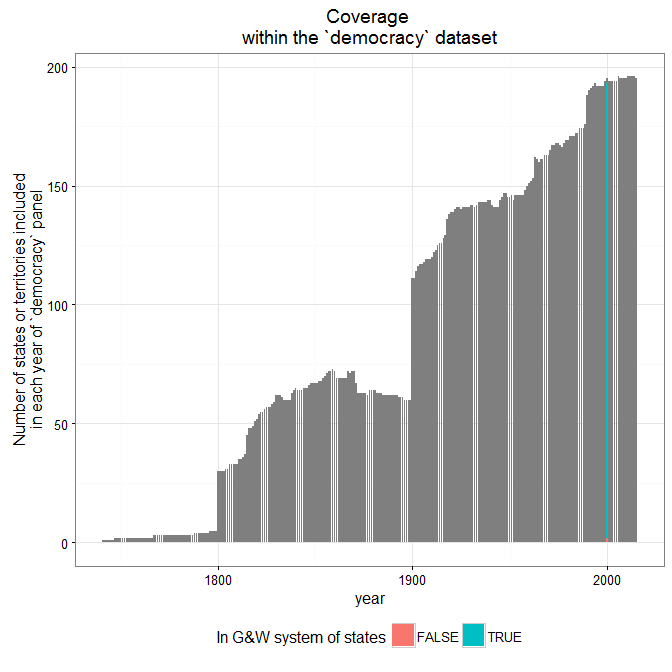

```r
spatial_coverage(data)
```

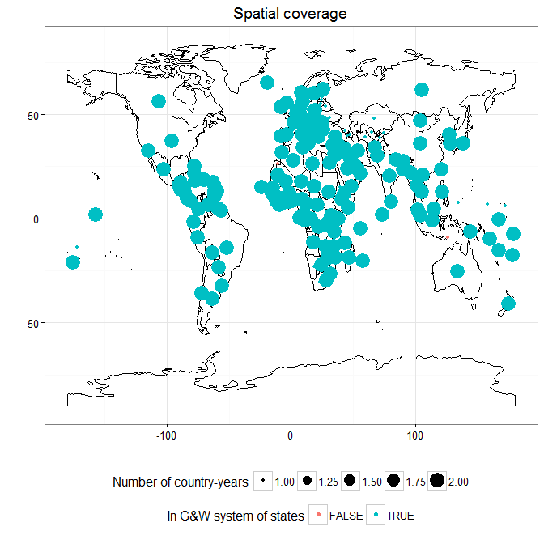

## Distribution

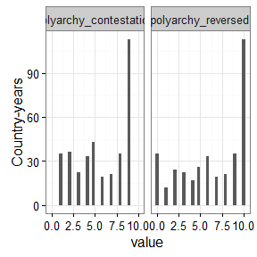

```r
data <- democracy_long %>% filter(variable %in% c("polyarchy_reversed","polyarchy_contestation"))

ggplot(data = data) +
  geom_histogram(aes(x=value)) +
  theme_bw() +
  theme(legend.position = "bottom") +
  labs(y = "Country-years") +
  facet_wrap(~variable, ncol=2)
```

```r
kable(democracy %>%
        filter(!is.na(polyarchy_reversed)) %>%
        count(polyarchy_reversed,polyarchy_contestation),
      caption = "Relationship between reversed polyarchy measure and polyarchy contestation measure")
```

| polyarchy_reversed | polyarchy_contestation | n |
| --- | --- | --- |
| 0 | 1 | 35 |
| 1 | 2 | 12 |
| 2 | 2 | 24 |
| 3 | 3 | 22 |
| 4 | 4 | 17 |
| 5 | 4 | 16 |
| 5 | 5 | 10 |
| 6 | 5 | 33 |
| 7 | 6 | 19 |
| 8 | 7 | 21 |
| 9 | 8 | 35 |
| 10 | 9 | 113 |

# Political Regime Change (PRC)/Gasiorowski dataset

The dataset first described in Gasiorowski 1996, and updated and revised in Reich 2002.

## Coverage

```r
data <- democracy_long %>% filter(variable == "prc")

temporal_coverage(data)
```

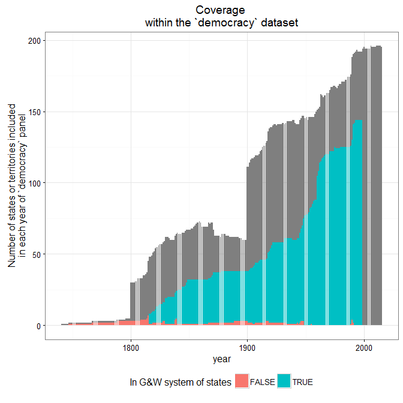

```r
spatial_coverage(data)
```

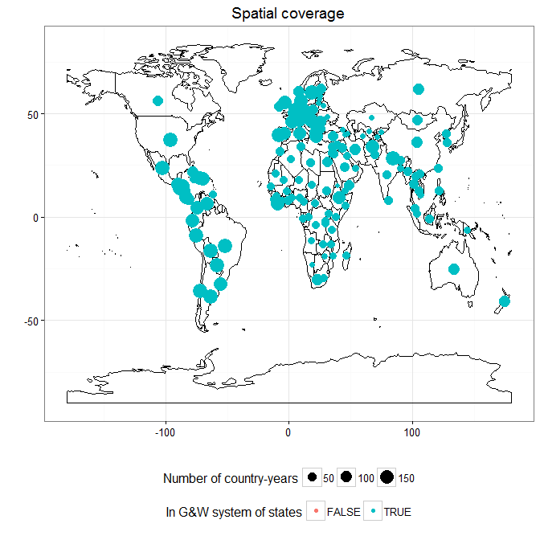

## Distribution

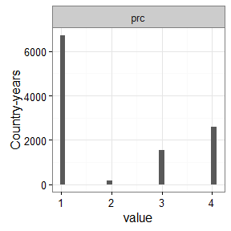

```r
ggplot(data = data) +
  geom_histogram(aes(x=value)) +
  theme_bw() +
  theme(legend.position = "bottom") +
  labs(y = "Country-years") +
  facet_wrap(~variable, ncol=2)
```

# PIPE

A constructed regime variable from Przeworski 2013 (the Political Institutions and Political Events (PIPE) Data Set).

## Coverage

```r
data <- democracy_long %>% filter(variable == "przeworski")

temporal_coverage(data)
```

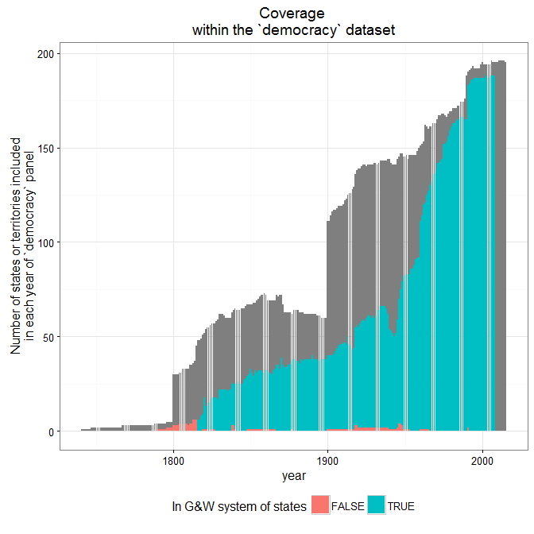

```r
spatial_coverage(data)
```

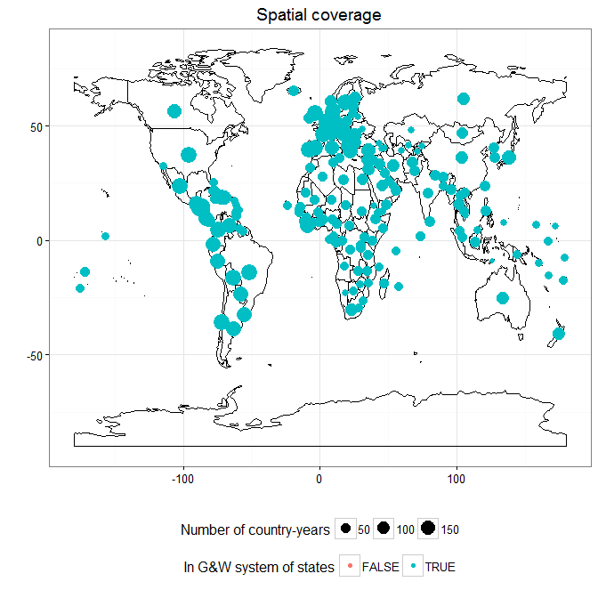

## Distribution

It is not clear that this index is correctly constructed, given the confusing documentation in the original dataset. Use with care.

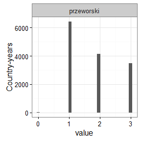

```r
ggplot(data = data) +
  geom_histogram(aes(x=value)) +
  theme_bw() +
  theme(legend.position = "bottom") +
  labs(y = "Country-years") +
  facet_wrap(~variable, ncol=2)
```

# Svolik

This uses a measure of democracy derived from the authoritarian regime dataset in Svolik 2012. The original data is extended to before 1946 using the information encoded in the `o_startdate` variable of the original dataset, which provides information for the start dates of some authoritarian regimes.

## Coverage

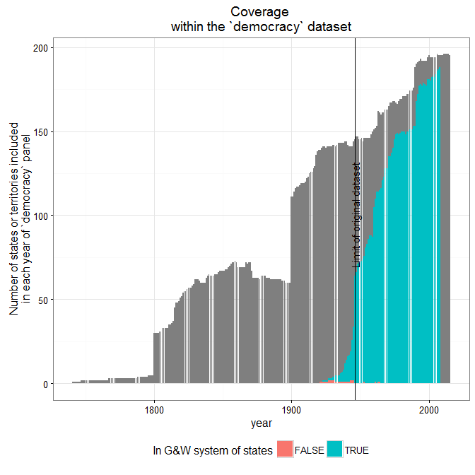

```r
data <- democracy_long %>% filter(variable == "svolik")

temporal_coverage(data) +
  geom_vline(xintercept = 1946) +
  annotate("text", label = "Limit of original dataset", x = 1946,y = 100, angle=90)
```

```r
spatial_coverage(data)
```

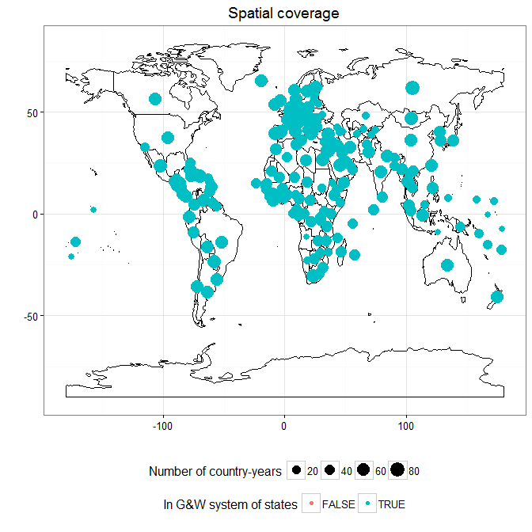

## Distribution

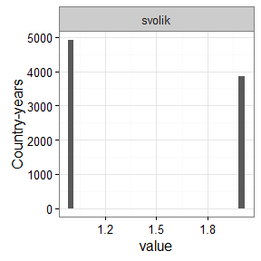

```r
ggplot(data = data) +
  geom_histogram(aes(x=value)) +
  theme_bw() +
  theme(legend.position = "bottom") +
  labs(y = "Country-years") +
  facet_wrap(~variable, ncol=2)
```

# Ulfelder

The dataset in Ulfelder 2012.

## Coverage

```r
data <- democracy_long %>% filter(variable == "ulfelder")

temporal_coverage(data)
```

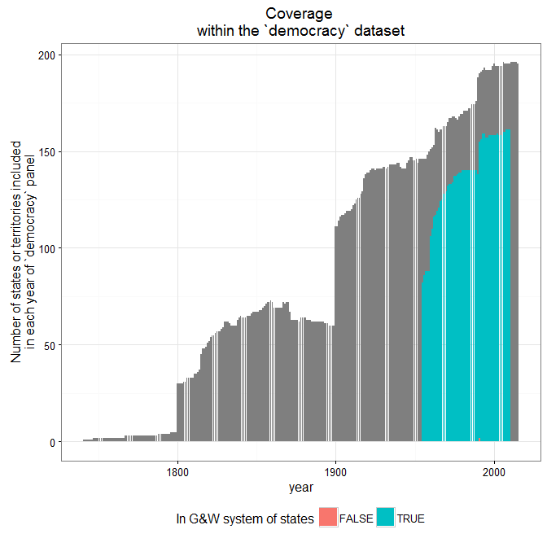

```r
spatial_coverage(data)
```

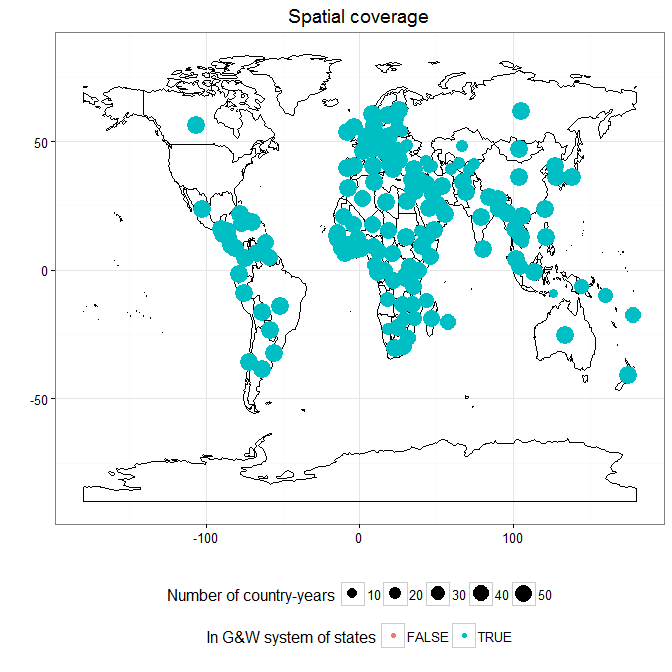

## Distribution

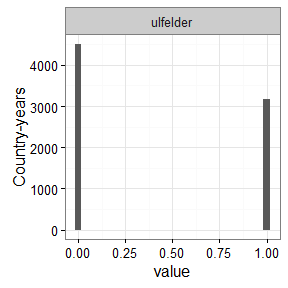

```r
ggplot(data = data) +
  geom_histogram(aes(x=value)) +
  theme_bw() +
  theme(legend.position = "bottom") +
  labs(y = "Country-years") +
  facet_wrap(~variable, ncol=2)
```

# UTIP

A measure of democracy from the regime type dataset described in Hsu 2008. This dataset identifies three types of democracies: “social democracies”, “conservative democracies”, and “one party democracies.” “One party democracies” are poorly documented, but seem to be equivalent to multiparty autocracies. `utip_dichotomous_strict` identifies as democracies only social or conservative democracies; `utip_dichotomous` also identifies as democracies those “one party democracies”; and `utip_trichotomous` assumes that “one party democracies” are hybrid regimes between democracy and non-democracy.

## Coverage

```r
data <- democracy_long %>% filter(variable == "utip_dichotomous")

temporal_coverage(data)
```

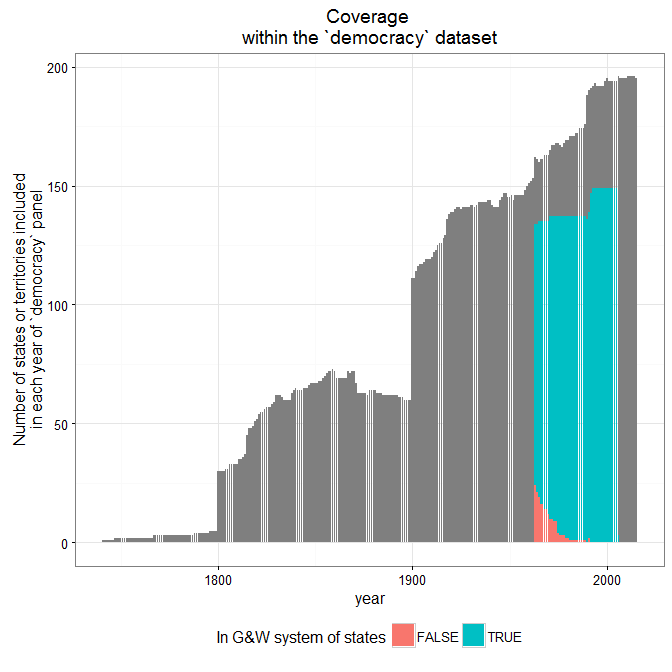

```r
spatial_coverage(data)
```

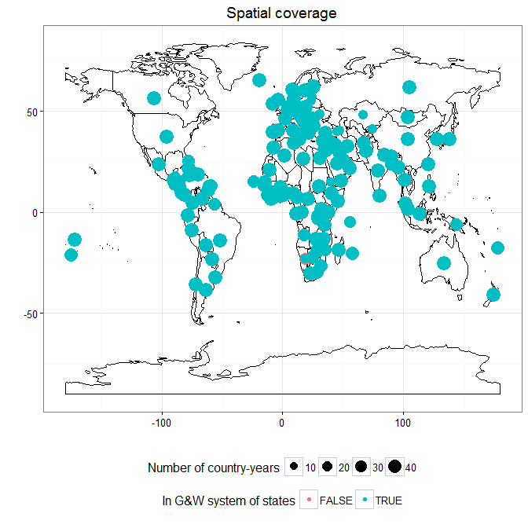

## Distribution

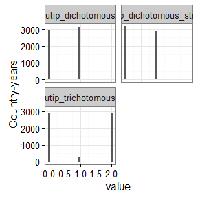

```r
data <- democracy_long %>% filter(variable %in% c("utip_dichotomous_strict","utip_dichotomous","utip_trichotomous"))

ggplot(data = data) +
  geom_histogram(aes(x=value)) +
  theme_bw() +
  theme(legend.position = "bottom") +
  labs(y = "Country-years") +
  facet_wrap(~variable, ncol=2)
```

# Vanhanen

This is the dataset in Vanhanen 2012.

## Coverage

```r
data <- democracy_long %>% filter(variable == "vanhanen_democratization")

temporal_coverage(data)
```

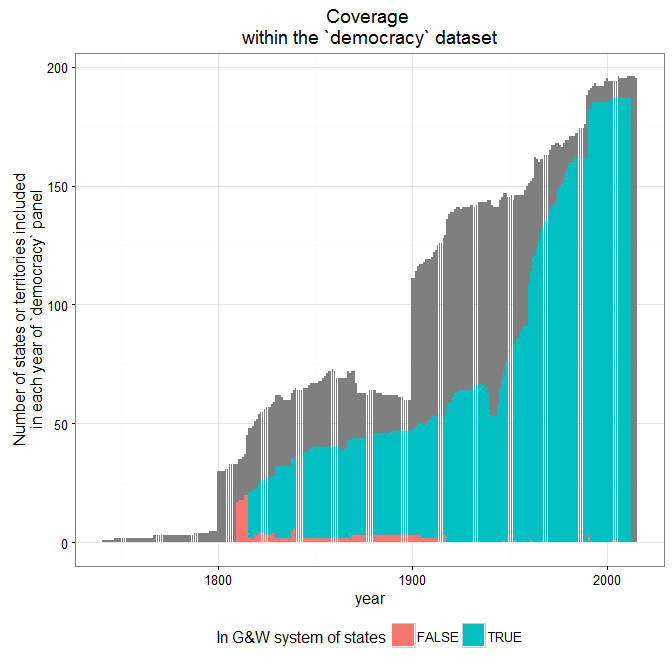

```r
spatial_coverage(data)
```

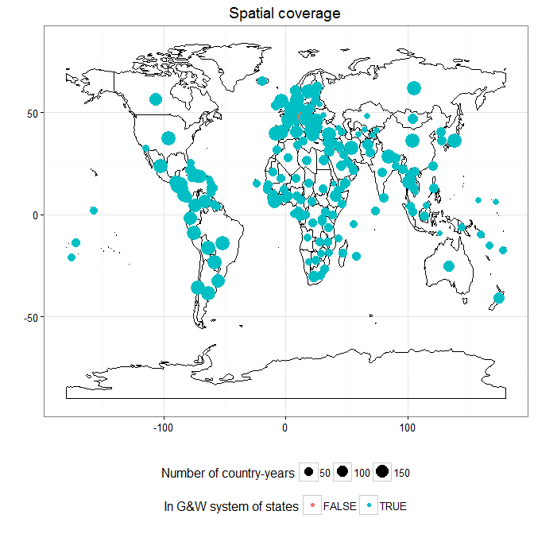

## Distribution

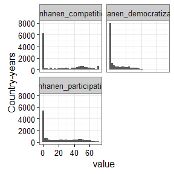

```r
data <- democracy_long %>% filter(variable %in% c("vanhanen_democratization","vanhanen_participation","vanhanen_competition"))

ggplot(data = data) +
  geom_histogram(aes(x=value)) +
  theme_bw() +
  theme(legend.position = "bottom") +
  labs(y = "Country-years") +
  facet_wrap(~variable, ncol=2)
```

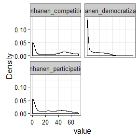

```r
ggplot(data = data) +
  geom_density(aes(x=value)) +
  theme_bw() +
  theme(legend.position = "bottom") +
  labs(y = "Density") +
  facet_wrap(~variable, ncol=2)
```

# V-Dem

This is a selection of the major democracy indexes from version 6 of the V-Dem dataset (`v2x*` variables) (Coppedge et al. 2016).

## Coverage

Most of the not in-system country-years in the main dataset are from V-Dem.

```r
data <- democracy_long %>% filter(variable == "v2x_polyarchy")

temporal_coverage(data)
```

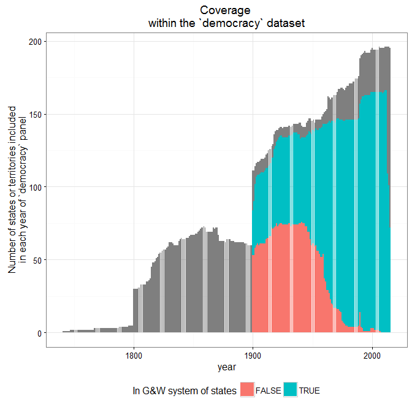

```r
spatial_coverage(data)
```

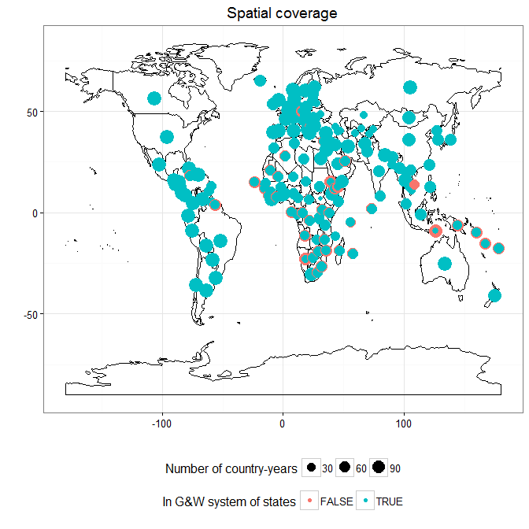

## Distribution

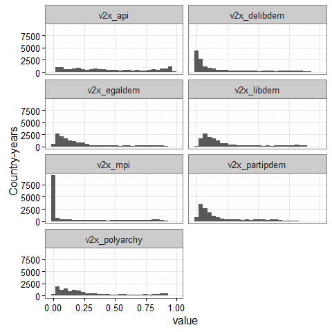

```r
data <- democracy_long %>% filter(grepl("v2x",variable))

ggplot(data = data) +
  geom_histogram(aes(x=value)) +
  theme_bw() +
  theme(legend.position = "bottom") +
  labs(y = "Country-years") +
  facet_wrap(~variable, ncol=2)
```

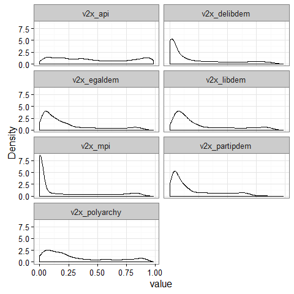

```r
ggplot(data = data) +
  geom_density(aes(x=value)) +
  theme_bw() +
  theme(legend.position = "bottom") +
  labs(y = "Density") +
  facet_wrap(~variable, ncol=2)
```

```r
ggcorr(data = democracy %>% select(v2x_api:v2x_polyarchy), label=TRUE,label_round=3, hjust=1) + scale_fill_gradient2(midpoint = 0.7)
```

[output not shown]

[figure not shown]